# esa_analysis

Bryan Milstead

07 July 2017

### to do

- change tax and tox read_excel to github links

## Introduction

- modified from Betty_NMSCode_20160824.R
- read taxonomy data
  - mutate: for is.na(genus_new) genus_new=genus (this will update any name changes.)
- read phyto counts (2007 and 2012)
- join taxonomy and counts
- filter
  - !is.na(phylum)-this eliminates data without a valid genus name
  - VISIT_NO==1
  - LAKE_SAMP==‘Target_Sampled’
- sum abundance by site_id and genus
- create datasets phyto07 and phyto12 by spreading genus and abund; replace NA with zeros
- create presense absence datasets phyto07pa and phyto12pa replacing values of abund>0 with ones
- create cyano07 and cyano12 by filtering for phylum==‘Cyanobacteria’
- create cyano07pa and cyano12pa
- decide how many dimensions to use for the NMS
- run the NMDS on the phyto abundances for 2007 and 2012
- run the NMDS on phyto presence/absence for 2007 and 2012
- run the NMDS on the cyano abundances for 2007 and 2012
- run the NMDS on cyano presence/absence for 2007 and 2012
- get the environmental data
- start with the env data from the ecosphere paper
- add Keith Loftins Toxin data
  - create detect fields for each toxin; 1=detect 2=non-detect;cyl_det, mic_det, & sax_det
  - create ‘tox_detects’ field to indicate the number of toxins detected (0-3)
  - create toxin Low Med High field for each toxin
    - cyl_tox_cat: non=[0,.05); low= [.05,1); med=[1,2); high=[2,inf); NOTE: low .05<= cyl < 1
    - mic_tox_cat: non=[0,.1); low= [.1,10); med=[10,20); high=[20,inf); Note: this is the who standard
    - sax_tox_cat: non=[0,.02); low= [.02,.1); med=[.1,.2); high=[.2,inf)
- add WHO standards for cyano cells counts
  - cyano_abund_cat: none=[0,1), low= [0,20k); med=[20k,100k); high=[100k,inf)
- add cat for cell counts of possible toxin producers
  - cyl_prod_abund_cat: none=[0,1), low= [0,20k); med=[20k,100k); high=[100k,inf)
  - mic_prod_abund_cat: none=[0,1), low= [0,20k); med=[20k,100k); high=[100k,inf)
  - sax_prod_abund_cat: none=[0,1), low= [0,20k); med=[20k,100k); high=[100k,inf)
- add NLA chla data (ug/l)
- add WHO standards for Chla (ug/l)
  - chla_cat: low= [0,10) med=[10,50) high=[50,inf)
- data definitions for the environmental data

| variable_names | description | type |
| --- | --- | --- |
| cyano_abund | cyano cell counts | cyano |
| cyano_abund_cat | WHO cyano category: none=[0,1), low= [0,20k); med=[20k,100k); high=[100k,inf) | cyano |
| site_id | unique NLA site id for lake | id |
| PercentImperv_3000m | % Impervious | GIS |
| WaterPer_3000m | % Water | GIS |
| IceSnowPer_3000m | % Ice/Snow | GIS |
| DevOpenPer_3000m | % Developed Open Space | GIS |
| DevLowPer_3000m | % Low Intensity Development | GIS |
| DevMedPer_3000m | % Medium Intensity Development | GIS |
| DevHighPer_3000m | % High Intensity Development | GIS |
| BarrenPer_3000m | % Barren | GIS |
| DeciduousPer_3000m | % Decidous Forest | GIS |
| EvergreenPer_3000m | % Evergreen Forest | GIS |
| MixedForPer_3000m | % Mixed Forest | GIS |
| ShrubPer_3000m | % Shrub/Scrub | GIS |
| GrassPer_3000m | % Grassland | GIS |
| PasturePer_3000m | % Pasture | GIS |
| CropsPer_3000m | % Cropland | GIS |
| WoodyWetPer_3000m | % Woody Wetland | GIS |
| HerbWetPer_3000m | % Herbaceuos Wetland | GIS |
| AlbersX | Longitude (Albers meters) | GIS |
| AlbersY | Latitude (Albers meters) | GIS |
| LakeArea | Lake Surface Area (sq. meters) | GIS |
| LakePerim | Lake Perimeter (meters) | GIS |
| ShoreDevel | Shoreline Development Index | GIS |
| DATE_COL | Date Samples Collected | NLA |
| WSA_ECO9 | Ecoregion | GIS |
| BASINAREA | Watershed Area (sq. meters) | GIS |
| DEPTHMAX | Maximum Depth (meters) | NLA |
| ELEV_PT | Elevation (meters) | GIS |

[output cut: 63 more lines]

- use envfit to compare NMDS scores and environmental gradient data
- Cluster Analysis
- setup ggplot of convex hull of sites by cluster group
- plot convex hull of sites by cluster group and points of potentially toxic producing species

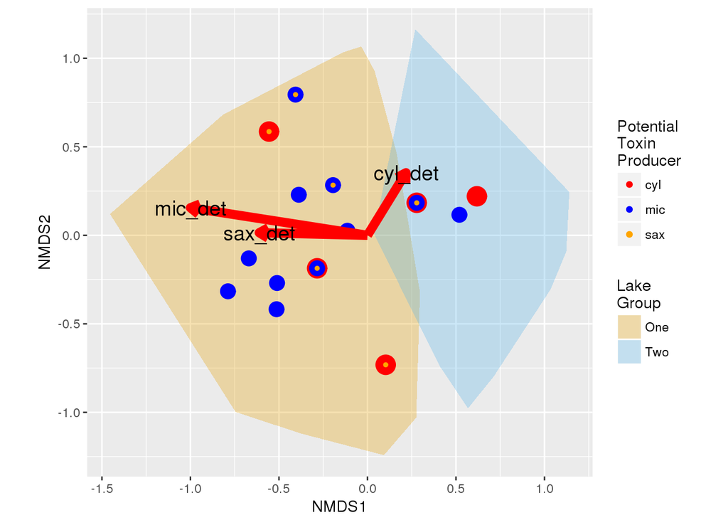

- color lake points by “lake_origin”

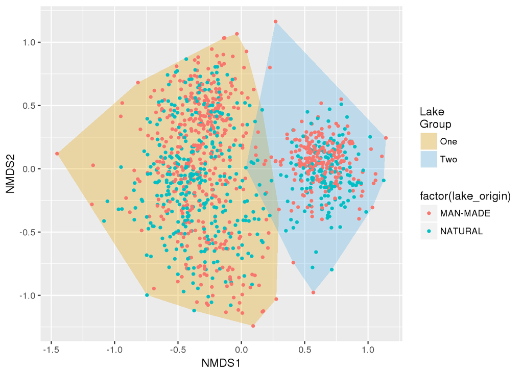

- color lake points by “WSA_ECO9”

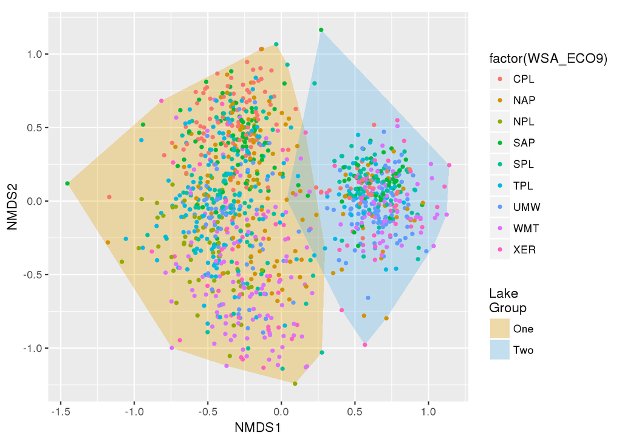

- color lake points by “chla_ca”

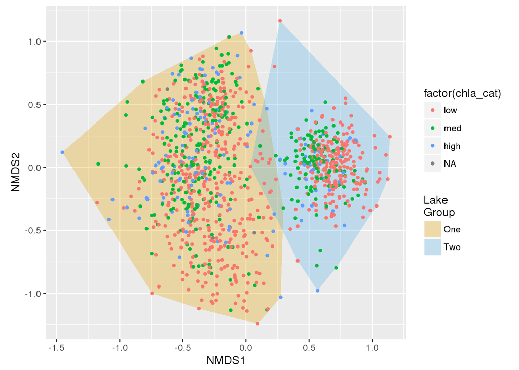

- color lake points by “mic_tox_cat”

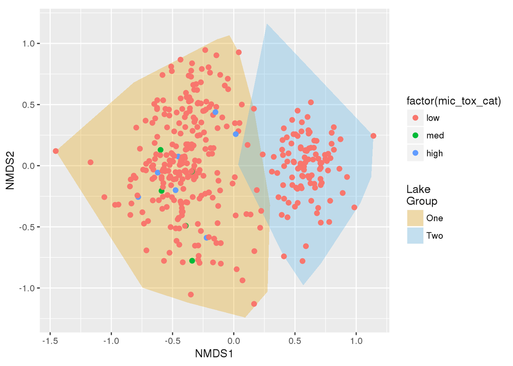

- color lake points by “cyl_tox_cat”

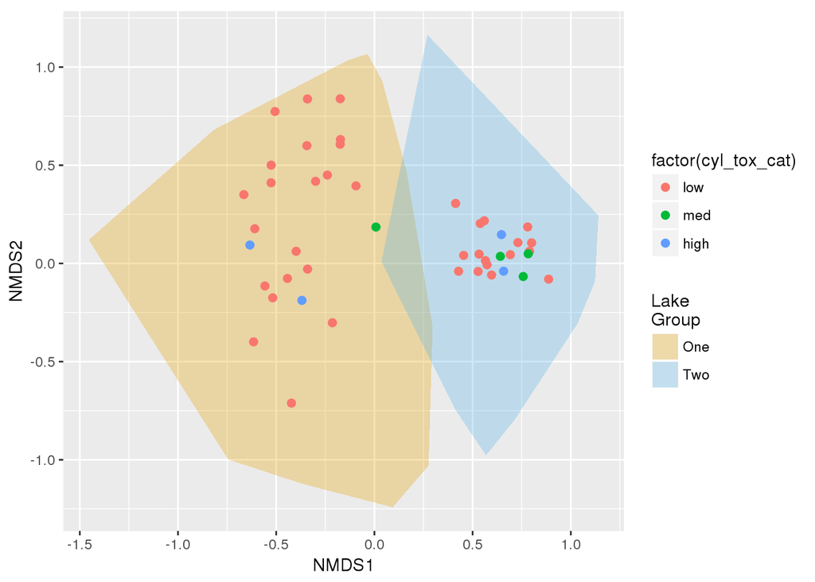

- color lake points by “sax_tox_cat”

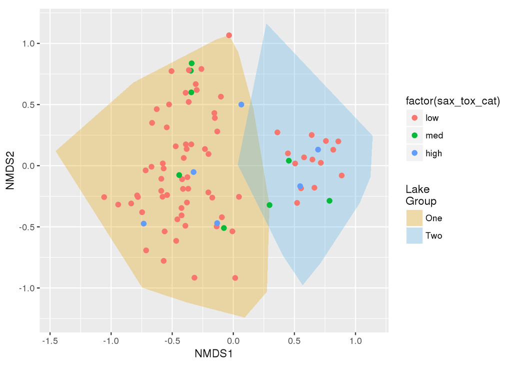

- 3d plot of scores
- biplot of envfit #https://stackoverflow.com/questions/14711470/plotting-envfit-vectors-vegan-package-in-ggplot2
- draw some box plots based on lake group
- random forest analysis of env variables to predict grp2
- random forest analysis of phyto variables to predict grp2

library(vegan) library(ggplot2) library(grid)

data(dune)

# calculate distance for NMDS

NMDS.log<-log1p(dune) set.seed(42) sol <- metaMDS(NMDS.log)

scrs <- as.data.frame(scores(scores, display = “sites”)) scrs <- cbind(scrs, Group = c(“hi”,“hi”,“hi”,“md”,“lo”,“hi”,“hi”,“lo”,“md”,“md”, “lo”,“lo”,“hi”,“lo”,“hi”,“md”,“md”,“lo”,“hi”,“lo”))

set.seed(123) vf <- envfit(sol, NMDS.log, perm = 999)

# So the r2 data is used to scale the values in columns NMDS1 and NMDS2. The final plot is produced with:

spp.scrs <- as.data.frame(scores(vf, display = “vectors”)) spp.scrs <- cbind(spp.scrs, Species = rownames(spp.scrs))

p <- ggplot(scrs) + geom_point(mapping = aes(x = NMDS1, y = NMDS2, colour = Group)) + coord_fixed() + ## need aspect ratio of 1! geom_segment(data = spp.scrs, aes(x = 0, xend = NMDS1, y = 0, yend = NMDS2), arrow = arrow(length = unit(0.25, “cm”)), colour = “grey”) + geom_text(data = spp.scrs, aes(x = NMDS1, y = NMDS2, label = Species), size = 3)